# Introduction to R

Malay K Basu (malay@uab.edu)

February 26-28, 2014

# History of R

R is the *lingua franca* of statistical software. It is a dialect of S, a computer language developed by John Chambers in 1976 at Bell Labs. In 1988, the system was rewritten in C. The software changed hand frequently, until in 1993, R appeared in the scene. It was a *free* implementation of S, written by Ross Ihaka and Robert Gentleman at the University of Auckland, New Zealand.

# Starting R

If you’re in command-line environment you can start `R` by typing the command `R`. In our example will will use a far nicer environment called RStudio. It is available from: https://www.rstudio.com/.

# R environment

1. **`getwd()`**

   Get the current directory
2. **`setwd()`**

   Set the current directory
3. **`ls()`**

   Lists the objects created.
4. **`rm()`**

   Will remove objects.
5. **`list.files()` or `dir()`**

   List the files in the current directory
6. **`source()`**

   Reads a R file

## Exercise

Create a file called `source_test.R` to have the following code.

```r
myfunction <- function() {
    x <- rnorm(100)
    mean(x)
}

addnoise <- function() {
    y <- x + rnorm(length(x))
}

ls()
```

```
## [1] "addnoise"   "myfunction"
```

Type `source("source_test.R")` in the R console. Type `ls()`, you’ll see two objects, `myfunction` and `adnoise` have been created.

# Getting help

1. `CRAN` - The Comprehensive R Archive Network (http://cran.r-project.org/). About ~4000 packages and data available for use.
2. R website (http://www.r-project.org/) and FAQs (http://cran.r-project.org/doc/FAQ/R-FAQ.html)
3. R related projects are difficult to search using Google. Use R-specific search engine RSEEK (http://www.rseek.org/).

## Online help

`help.search("functionname")` will search the help page of the a function name. You can also search the help page by putting `"?"` before the function, e.g., `?plot`.

## Some useful online documentation

1. An introduction to R (http://cran.r-project.org/doc/manuals/r-release/R-intro.pdf)
2. R Data Import/Export (http://cran.r-project.org/doc/manuals/r-release/R-data.pdf)

A full list of such manuals can be found at http://cran.r-project.org/manuals.html.

## R for bioinformatics

1. **Bioconductor project http://www.bioconductor.org/**

   A set of R modules specifically meant for biological data analysis. Distributed separately from CRAN.
2. Some biological data related module in CRAN, such as [`ape`](http://cran.r-project.org/web/packages/ape/index.html), a phylogenetic analysis package. Or, [`seqinr`](http://cran.r-project.org/web/packages/seqinr/index.html), a basic sequence analysis package. A brief introduction to using R for bioinformatics can be found [here](http://cran.r-project.org/doc/contrib/Krijnen-IntroBioInfStatistics.pdf).

# Installing packages in R

`install.packages('Packagename')` will install any package in R. To use the package you need to use `library('Packagename')`.

# Assignment

Assignment operator in R is `<-`.

```r
x <- 1:20
x
```

```
##  [1]  1  2  3  4  5  6  7  8  9 10 11 12 13 14 15 16 17 18 19 20
```

# Basic data types in R

1. character
2. numeric All numbers in R are double precision real numbers. If you want an integer, you need to specify `L` suffix. `1` is `numeric`, but `1L` is integer.
3. integer
4. complex
5. logical (True/False)

Undefined data in R is represented as either ‘NaN’ or ‘NA’ types. Infinity is represented as `Inf`.

# R data structures

## Vectors and List

1. A `array` like objects. Vector contains only one type of objects.
2. A list can contain various data types.
3. Empty vector can be created using `vector()` function.
4. Empty list can be created using `list()` function.
5. Properties are `attributes()`, `class()`, `length()`.
6. Individual elements can be *concatenated* using `c()` function.
7. Can be converted to other data types using `as.x()` functions.

```r
x <- 0:6
as.numeric(x)
```

```
## [1] 0 1 2 3 4 5 6
```

```r
as.logical(x)
```

```
## [1] FALSE  TRUE  TRUE  TRUE  TRUE  TRUE  TRUE
```

```r
as.character(x)
```

```
## [1] "0" "1" "2" "3" "4" "5" "6"
```

```r
as.complex(x)
```

```
## [1] 0+0i 1+0i 2+0i 3+0i 4+0i 5+0i 6+0i
```

## Matrix

Special type of vector with “dimension” attributes.

```r
m <- matrix(nrow = 2, ncol = 3)
dim(m)
```

```
## [1] 2 3
```

```r
attributes(m)
```

```
## $dim
## [1] 2 3
```

Matrix is constructed column-wise.

```r
m <- matrix(1:6, nrow = 2, ncol = 3)
m
```

```
##      [,1] [,2] [,3]
## [1,]    1    3    5
## [2,]    2    4    6
```

```r
m <- 1:10
dim(m) <- c(2, 5)
m
```

```
##      [,1] [,2] [,3] [,4] [,5]
## [1,]    1    3    5    7    9
## [2,]    2    4    6    8   10
```

You can create matrix out of vectors using column-binding or row-binding:

```r
x <- 1:3
y <- 10:12
cbind(x, y)
```

```
##      x  y
## [1,] 1 10
## [2,] 2 11
## [3,] 3 12
```

```r
rbind(x, y)
```

```
##   [,1] [,2] [,3]
## x    1    2    3
## y   10   11   12
```

## Factor

Categorical data. Can be ordered or unordered.

```r
x <- factor(c("yes", "yes", "no"))
```

Factors have levels:

```r
table(x)
```

```
## x
##  no yes
##   1   2
```

Factors are basically numerical data under the hood. Each string is given a number. We can view the underlying assignment using this:

```r
unclass(x)
```

```
## [1] 2 2 1
## attr(,"levels")
## [1] "no"  "yes"
```

```r
x <- factor(c("yes", "no"), levels = c("Yes", "no"))
```

## Missing values

Undefined values in R are represented by `"NaN"` and `"NA"`. NA values can have class of numeric, integer, etc. NaN is also NA but the converse is not true. There are two functions to find `NaN` and `NA` is R:

```
is.na()
is.nan()
```

```r
x <- c(1, 2, NA, 10, 3)
is.na(x)
```

```
## [1] FALSE FALSE  TRUE FALSE FALSE
```

```r
is.nan(x)
```

```
## [1] FALSE FALSE FALSE FALSE FALSE
```

```r
x <- c(1, 2, NaN, NA, 4)
is.na(x)
```

```
## [1] FALSE FALSE  TRUE  TRUE FALSE
```

```r
is.nan(x)
```

```
## [1] FALSE FALSE  TRUE FALSE FALSE
```

## Data frames

Key data type in R. It stores tabular data. Column of a data frame can have different types of data, unlike matrix (same type). Special attributes `row.names`. To read use `read.table()` or `read.csv()`. Data frame can be converted to matrix `data.matrix()`.

```r
x <- data.frame(foo = 1:4, bar = c(T, T, F, F))
x
```

```
##   foo   bar
## 1   1  TRUE
## 2   2  TRUE
## 3   3 FALSE
## 4   4 FALSE
```

```r
nrow(x)
```

```
## [1] 4
```

```r
ncol(x)
```

```
## [1] 2
```

### Reading and writing data-frame

```r
data(iris)  # Read iris data sets
head(iris)  # View the first few line of the iris data
```

```
##   Sepal.Length Sepal.Width Petal.Length Petal.Width Species
## 1          5.1         3.5          1.4         0.2  setosa
## 2          4.9         3.0          1.4         0.2  setosa
## 3          4.7         3.2          1.3         0.2  setosa
## 4          4.6         3.1          1.5         0.2  setosa
## 5          5.0         3.6          1.4         0.2  setosa
## 6          5.4         3.9          1.7         0.4  setosa
```

```r
write.table(iris, "iris.txt", quote = F)  # Write a sample file out
dir()  # Check that we have written a file
```

```
##  [1] "airquality.pdf"    "figure"            "final_problems.md"
##  [4] "gbs_746-1.2.pdf"   "gbs_746.mdown"     "gbs_746.pdf"
##  [7] "Intro_to_R.html"   "Intro_to_R.md"     "Intro_to_R.mdown"
## [10] "Intro_to_R.pdf"    "Intro_to_R.rmd"    "iris.txt"
## [13] "knit.R"            "Makefile"          "r_style_files"
## [16] "r_style.html"      "Rplots.pdf"
```

```r
test_data <- read.table("iris.txt", header = T)  # read the data back into test_data
head(test_data)  # Check the first few lines of the data
```

```
##   Sepal.Length Sepal.Width Petal.Length Petal.Width Species
## 1          5.1         3.5          1.4         0.2  setosa
## 2          4.9         3.0          1.4         0.2  setosa
## 3          4.7         3.2          1.3         0.2  setosa
## 4          4.6         3.1          1.5         0.2  setosa
## 5          5.0         3.6          1.4         0.2  setosa
## 6          5.4         3.9          1.7         0.4  setosa
```

To read a data frame from a gzipped file:

```r
d <- read.table(gzfile("myzipped.gz"))
```

# Names

Each type of of data in R can have names. But they are most important for Matrix and Data-frames.

```r
m <- matrix(1:4, nrow = 2, ncol = 2)
dimnames(m) <- list(c("a", "b"), c("c", "d"))
m
```

```
##   c d
## a 1 3
## b 2 4
```

```r
d <- data.frame(c(1, 2, 3), c(4, 5, 6))
d
```

```
##   c.1..2..3. c.4..5..6.
## 1          1          4
## 2          2          5
## 3          3          6
```

```r
names(d) <- c("A", "B")
d
```

```
##   A B
## 1 1 4
## 2 2 5
## 3 3 6
```

# Subsetting

Subsetting is a way to select a subset of data. There are 3 basic ways to subset data in R:

1. `[]`
2. `[[]]`
3. `$`

## Subsetting vector

```r
x <- c("a", "b", "c")
x[1]
```

```
## [1] "a"
```

```r
x[2]
```

```
## [1] "b"
```

```r
x[1:3]
```

```
## [1] "a" "b" "c"
```

```r
x[-2]
```

```
## [1] "a" "c"
```

```r
x[x > "a"]
```

```
## [1] "b" "c"
```

```r
u <- x > "a"
u
```

```
## [1] FALSE  TRUE  TRUE
```

```r
x[u]
```

```
## [1] "b" "c"
```

## Subsetting list

```r
x <- list(foo = 1:4, bar = 0.6)
x[1]
```

```
## $foo
## [1] 1 2 3 4
```

```r
x[[1]]
```

```
## [1] 1 2 3 4
```

```r
x$bar
```

```
## [1] 0.6
```

```r
x[["bar"]]
```

```
## [1] 0.6
```

```r
x["bar"]
```

```
## $bar
## [1] 0.6
```

## Removing missing values

```r
x <- c(1, 2, NA, 4, NA, 5)
bad <- is.na(x)
x[!bad]
```

```
## [1] 1 2 4 5
```

## Matrix subsetting

```r
x <- matrix(1:6, 2, 3)  # Create a sample 2x3 matrix
x  # print the matrix out
```

```
##      [,1] [,2] [,3]
## [1,]    1    3    5
## [2,]    2    4    6
```

```r
x[1, 2]  # what is the value in row 1, column 2
```

```
## [1] 3
```

```r
x[2, 1]  # what is the value in row 2, column 1
```

```
## [1] 2
```

We can select the whole row or columns:

```r
x[1, ]  # select whole row 1
```

```
## [1] 1 3 5
```

```r
x[, 2]  # select whole column 2
```

```
## [1] 3 4
```

## Subsetting data-frame

All the operations of matrix also work with data-frame. However, you will more often use `$` to extract individual columns of a data-frame.

```r
x <- data.frame(c(1:3), c(4:6))  # create a small data frame
names(x) <- c("A", "B")  # Give each column a nice name
x
```

```
##   A B
## 1 1 4
## 2 2 5
## 3 3 6
```

```r
x$A  # Extract the column A
```

```
## [1] 1 2 3
```

# Vectorized operations

Instead of using loops, you should all the time try to use “vectorized” operations. That means if you are interested in operations performed on each element of a “collection”, you should use the collection as a whole, not individual elements. This gives the computer to parallelize the operation and usually results in faster runtime.

```r
x <- 1:4
y <- 6:9
x + y
```

```
## [1]  7  9 11 13
```

```r
x - y
```

```
## [1] -5 -5 -5 -5
```

```r
x * y
```

```
## [1]  6 14 24 36
```

```r
x/y
```

```
## [1] 0.1667 0.2857 0.3750 0.4444
```

When you multiply two matrices using the `"*"`, it multiplies element by element multiplications. This is different that standard matrix multiplication. If you are interested standard matrix multiplication, use `"%*%"` operator.

```r
m1 <- matrix(1:4, 2, 2)
m1
```

```
##      [,1] [,2]
## [1,]    1    3
## [2,]    2    4
```

```r
m1 * m1
```

```
##      [,1] [,2]
## [1,]    1    9
## [2,]    4   16
```

```r
m1 %*% m1
```

```
##      [,1] [,2]
## [1,]    7   15
## [2,]   10   22
```

# Some programming concepts in R

## Functions

```r
myfunction <- function() {
    cat("Hello world\n")
}
```

## For loop and if condition

```r
for (i in 1:3) {
    if (i > 1) {
        cat("I said hello", i, "times\n")
    } else {
        cat("I said hello", i, "time\n")
    }
}
```

```
## I said hello 1 time
## I said hello 2 times
## I said hello 3 times
```

# Summary statistics

```r
x <- rnorm(50)
mean(x)
```

```
## [1] 0.2844
```

```r
sd(x)
```

```
## [1] 0.9511
```

```r
var(x)
```

```
## [1] 0.9046
```

```r
median(x)
```

```
## [1] 0.3103
```

```r
sum(x)
```

```
## [1] 14.22
```

You need to skip `NA` for doing summary statistics:

```r
data(airquality)
mean(airquality$Ozone)
```

```
## [1] NA
```

```r
mean(airquality$Ozone, na.rm = T)
```

```
## [1] 42.13
```

`summary()` will give you a nice summary of data:

```r
summary(airquality)
```

```
##      Ozone          Solar.R         Wind            Temp
##  Min.   :  1.0   Min.   :  7   Min.   : 1.70   Min.   :56.0
##  1st Qu.: 18.0   1st Qu.:116   1st Qu.: 7.40   1st Qu.:72.0
##  Median : 31.5   Median :205   Median : 9.70   Median :79.0
##  Mean   : 42.1   Mean   :186   Mean   : 9.96   Mean   :77.9
##  3rd Qu.: 63.2   3rd Qu.:259   3rd Qu.:11.50   3rd Qu.:85.0
##  Max.   :168.0   Max.   :334   Max.   :20.70   Max.   :97.0
##  NA's   :37      NA's   :7
##      Month           Day
##  Min.   :5.00   Min.   : 1.0
##  1st Qu.:6.00   1st Qu.: 8.0
##  Median :7.00   Median :16.0
##  Mean   :6.99   Mean   :15.8
##  3rd Qu.:8.00   3rd Qu.:23.0
##  Max.   :9.00   Max.   :31.0
##
```

# Random numbers

We can generate random numbers from the normal distribution using `rnorm()` function.

```r
x <- rnorm(10)
x
```

```
##  [1] -1.5152 -0.4647  2.4993 -0.1411  1.0314  0.5282  0.0562 -0.3260
##  [9] -0.6591 -0.3245
```

If we are interested in generating random numbers using a particular mean and standard deviation, we should you this:

```r
x <- rnorm(10, mean = 5, sd = 2)
x
```

```
##  [1] 2.710 3.107 3.573 5.697 3.507 6.808 5.742 3.548 3.792 3.006
```

In R, you can sample other distributions, I will leave it up to you to explore.

# Plotting in R

There are 3 graphical libraries in R:

1. Base graphics
2. Lattice
3. `gglplot2()`

In this tutorial we will discuss only base graphics.

## `Plot`

`plot` function is pretty intelligent. If you just give a dataframe, it will plot a graph with all vs all variables.

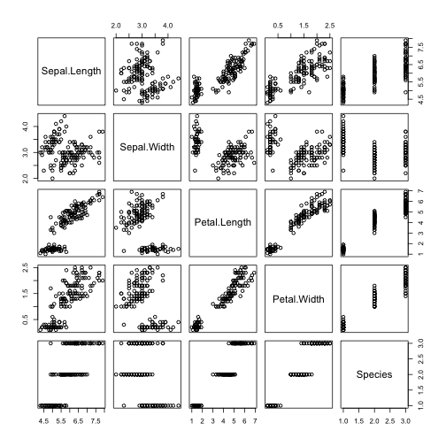

```r
data(iris)
plot(iris)
```

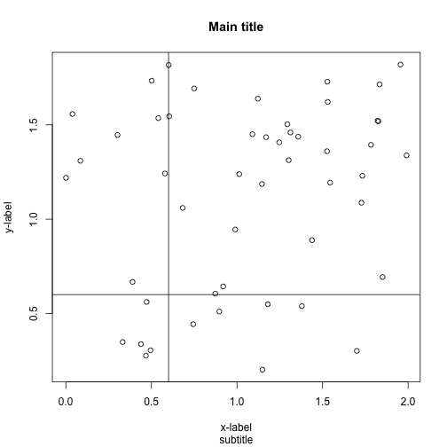

```r
x <- runif(50, 0, 2)  # create a vector from uniform distribution
y <- runif(50, 0, 2)  # create another one
plot(x, y, main = "Main title", sub = "subtitle", xlab = "x-label", ylab = "y-label")
abline(h = 0.6, v = 0.6)
```

Each side of the plot have specific margins.

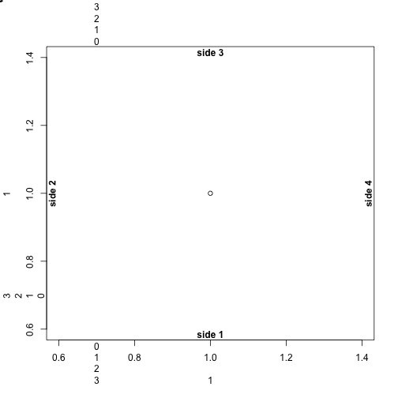

```r
plot(1, 1)
for (side in 0:3) mtext(0:3, side = side, at = 0.7, line = 0:3)
mtext(paste("side", 1:4), side = 1:4, line = -1, font = 2)
```

### Building a plot from pieces

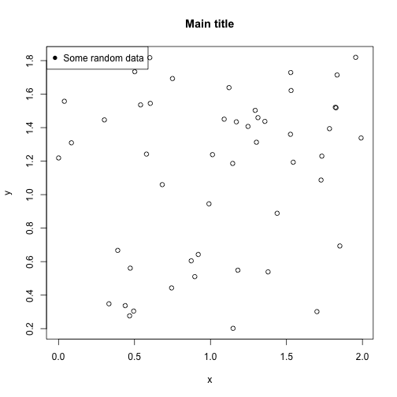

```r
plot(x, y, type = "n", xlab = "", ylab = "", axes = F)  # Draw an empty plot area
points(x, y)  # Draw point
axis(1)  # Draw the first axis
axis(2, at = seq(0.2, 1.8, 0.2))  # Draw second axis with tick at specific scale
box()  # Draw the surrounding box
title(main = "Main title", xlab = "x", ylab = "y")  # Write the main title and the labels
legend("topleft", legend = "Some random data", pch = 16)
```

### Plotting characters

`pchShow()` will show you all the plotting characters.

## Drawing devices in R

Normally when you create a plot, it is drawn on the default computer screen. But you can create all sorts of images, such PDF (good for high resolution publication quality graphs), or bitmap images such as PNG. In all cases, the steps are identical. You open a device, draw your plot and close the device. For e.g., you can create a PDF drawing like this.

```r
data(airquality)
pdf("airquality.pdf", width = 8.5, height = 11)
plot(airquality)
dev.off()
```

## `par`

`par` function controls every parameter of a plot. The function has several parameters. But the most common ones are as follows:

1. `pch`- point type used for plotting
2. `lty` - Line type
3. `lwd` - line width
4. `cex` - character magnification. It has several variations for different regions of the plot.
5. `las` - rotation of the axis labels
6. `bg` - background color of the plot
7. `mar` - margin of the plot
8. `oma` - outer margin of the plot
9. `mfrow` - draws multiple plots

## Drawing multiplots

You can modify `mfrow` in `par()`. For e.g, to draw a 1 row two column plot,

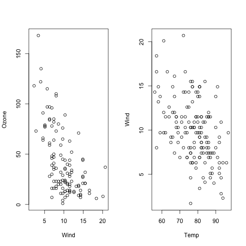

```r
data(airquality)
par(mfrow = c(1, 2))
with(airquality, {
    plot(Wind, Ozone)
    plot(Temp, Wind)
})
```

## Histograms

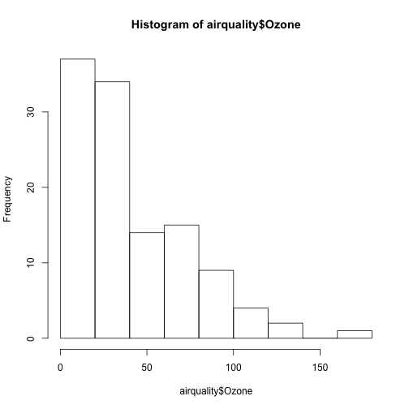

```r
data("airquality")
hist(airquality$Ozone)
```

No of breaks in the histogram can be controlled:

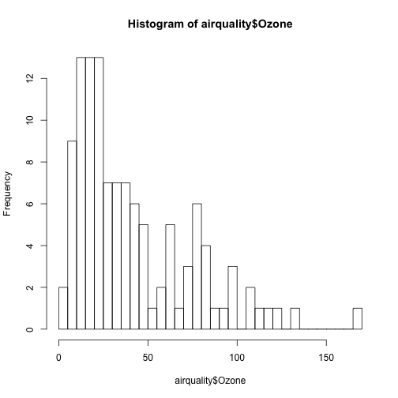

```r
hist(airquality$Ozone, breaks = 50)
```

## Boxplots

Boxplot is an summary plot showing the median and the distributions of data. You can give it a data frame.

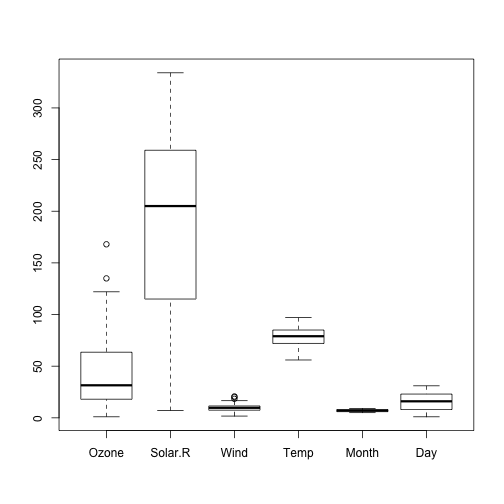

```r
boxplot(airquality)
```

## Barplots

```r
data(mtcars)
head(mtcars)
```

```
##                    mpg cyl disp  hp drat    wt  qsec vs am gear carb
## Mazda RX4         21.0   6  160 110 3.90 2.620 16.46  0  1    4    4
## Mazda RX4 Wag     21.0   6  160 110 3.90 2.875 17.02  0  1    4    4
## Datsun 710        22.8   4  108  93 3.85 2.320 18.61  1  1    4    1
## Hornet 4 Drive    21.4   6  258 110 3.08 3.215 19.44  1  0    3    1
## Hornet Sportabout 18.7   8  360 175 3.15 3.440 17.02  0  0    3    2
## Valiant           18.1   6  225 105 2.76 3.460 20.22  1  0    3    1
```

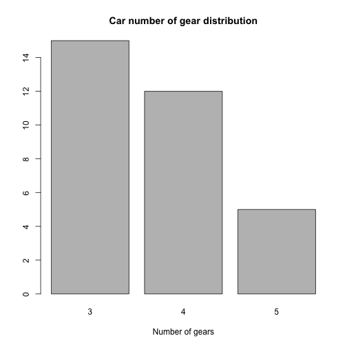

```r
counts <- table(mtcars$gear)
barplot(counts, main = "Car number of gear distribution", xlab = "Number of gears")
```

You can make a horizontal bar plot.

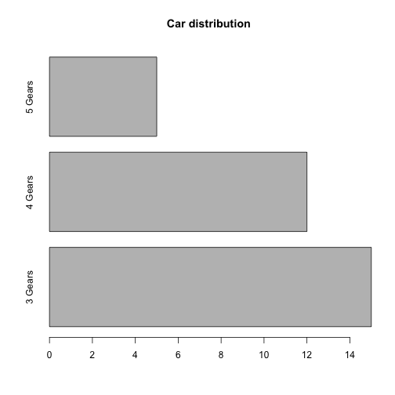

```r
barplot(counts, main = "Car distribution", horiz = T, names.arg = c("3 Gears",
    "4 Gears", "5 Gears"))
```

You can draw a grouped bar plot like this.

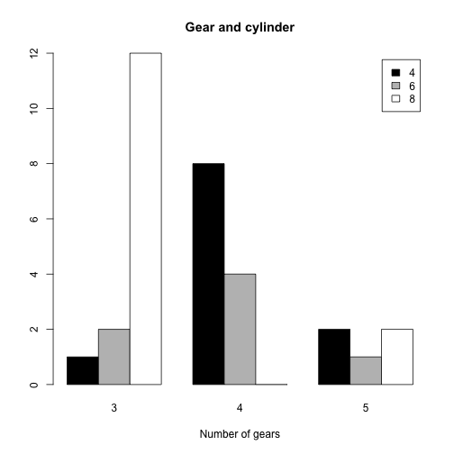

```r
counts <- table(mtcars$cyl, mtcars$gear)
barplot(counts, main = "Gear and cylinder", xlab = "Number of gears", col = c("black",
    "grey", "white"), legend = rownames(counts), beside = T)
```

## Barplots with error bars

There is no inbuilt way to generate error bars in R. But we have to hack a solution. We will use arrows to generate error bars. The trick is arrows take an argument of `angle`. If you give `angle=90` it will generate an error bar.

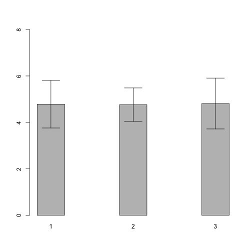

```r
## Generate some data
heights <- vector()  # Empty vector to hold the heights of the bar plot
stddevs <- vector()  # Empty vector to hold the standard deviations

for (i in 1:3) {
    # We will generate 3 sets of data
    d <- rnorm(10, mean = 5, sd = 1)  # Be sure that we have some positive data
    heights[i] <- mean(d)
    stddevs[i] <- sd(d)
}

## Draw the barplot
bp <- barplot(heights, names = c(1:3), ylim = c(0, 8), space = 2)  # Returns a matrix
mids <- bp[, 1]  # Get the midpoint

for (i in 1:3) {
    # We will draw the errorbars
    arrows(x0 = mids[i], y0 = heights[i] - stddevs[i], x1 = mids[i], y1 = heights[i] +
        stddevs[i], code = 3, angle = 90)
}
```

# Colors in R

If you have drawn figures in Excel, you might have used colors like this

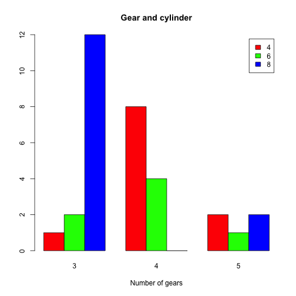

```r
barplot(counts, main = "Gear and cylinder", xlab = "Number of gears", col = c("red",
    "green", "blue"), legend = rownames(counts), beside = T)
```

This is what I call “Christmas” plot. You should never use color like this. In R you can use sophisticated color palette.

```r
library(RColorBrewer)
display.brewer.all()
```

[figure not shown]

There are 3 palettes: sequential, quantitative, and contrasting. Now choose a nice color for our plot.

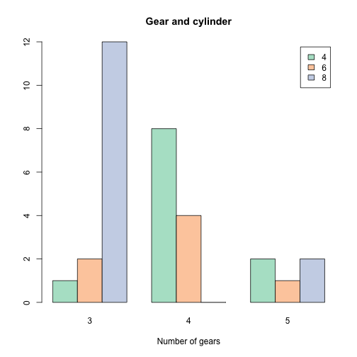

```r
nice <- brewer.pal(3, "Pastel2")
barplot(counts, main = "Gear and cylinder", xlab = "Number of gears", col = nice,
    legend = rownames(counts), beside = T)
```

# Linear regression and correlation

## Linear regression

We will use the `women` datasets in R for this example. These is a simple datasets with “weight” and “height” of women in the US.

```r
data(women)
head(women)
```

```
##   height weight
## 1     58    115
## 2     59    117
## 3     60    120
## 4     61    123
## 5     62    126
## 6     63    129
```

If we plot a simple scatterplot of this data, we will see there is an obvious correlation between this two variables.

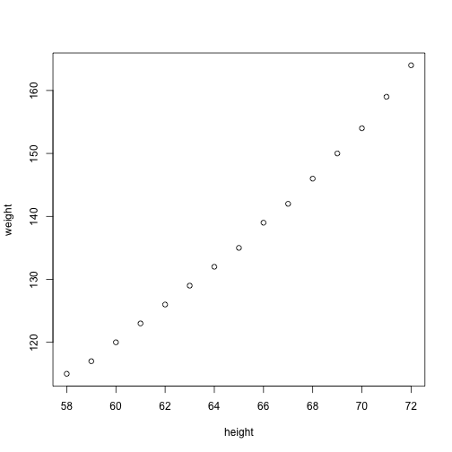

```r
plot(women)
```

Let’s do a linear regression between this two variables.

```r
l <- lm(women$weight ~ women$height)
summary(l)
```

```
##
## Call:
## lm(formula = women$weight ~ women$height)
##
## Residuals:
##    Min     1Q Median     3Q    Max
## -1.733 -1.133 -0.383  0.742  3.117
##
## Coefficients:
##              Estimate Std. Error t value Pr(>|t|)
## (Intercept)  -87.5167     5.9369   -14.7  1.7e-09 ***
## women$height   3.4500     0.0911    37.9  1.1e-14 ***
## ---
## Signif. codes:  0 '***' 0.001 '**' 0.01 '*' 0.05 '.' 0.1 ' ' 1
##
## Residual standard error: 1.53 on 13 degrees of freedom
## Multiple R-squared:  0.991,  Adjusted R-squared:  0.99
## F-statistic: 1.43e+03 on 1 and 13 DF,  p-value: 1.09e-14
```

You can safely ignore the `(Intercept)` line. But the adjusted r<sup>2</sup> is 0.99 with P-value 1.1e-14, which is highly significant. Let’s put the regression line on the plot.

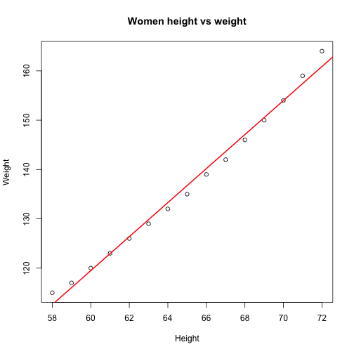

```r
plot(women$height, women$weight, main = "Women height vs weight", xlab = "Height",
    ylab = "Weight")
abline(l, lwd = 2, col = "red")
```

You can extract the P-value and the r<sup>2</sup> values for printing

```r
s <- summary(l)
s$adj.r.squared
```

```
## [1] 0.9903
```

```r
s$coefficients[2, 4]
```

```
## [1] 1.091e-14
```

## Correlations

We can also do a correlation between this two variables

```r
s <- cor.test(women$weight, women$height, alternatives = "tow.sided")
s
```

```
##
##  Pearson's product-moment correlation
##
## data:  women$weight and women$height
## t = 37.86, df = 13, p-value = 1.088e-14
## alternative hypothesis: true correlation is not equal to 0
## 95 percent confidence interval:
##  0.9861 0.9985
## sample estimates:
##    cor
## 0.9955
```

```r
s$p.value
```

```
## [1] 1.088e-14
```

```r
s$estimate
```

```
##    cor
## 0.9955
```